# Chapter 2: Statistical Learning

[figure not shown]

Credit: https://www.instagram.com/sandserifcomics/

# 1 What is Statistical Learning?

A scenario: We are consultants hired by a client to provide advice on how to improve sales of a product.

| TV | radio | newspaper | sales |
| --- | --- | --- | --- |
| 230.1 | 37.8 | 69.2 | 22.1 |
| 44.5 | 39.3 | 45.1 | 10.4 |
| 17.2 | 45.9 | 69.3 | 9.3 |
| 151.5 | 41.3 | 58.5 | 18.5 |

We have the advertising budgets for that product in 200 markets and the sales in those markets. It is not possible to increase sales directly, but the client can change how they budget for advertising. **How should we advise our client?**

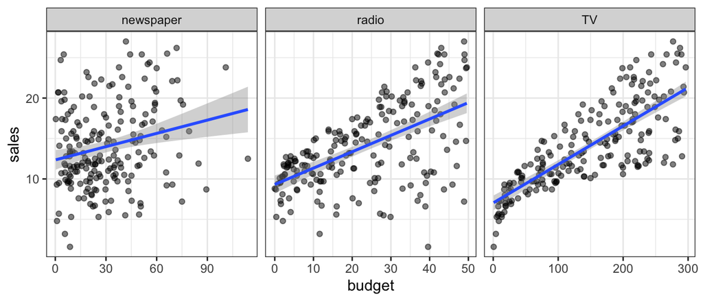

**input variables**

**output variable**

More generally –

$$Y = f(X) + e.$$

Essentially, *statistical learning* is a set of approaches for estimating $f$.

## 1.1 Why estimate $f$?

There are two main reasons we may wish to estimate $f$.

**Prediction**

In this case, $\hat{f}$ is often treated as a “black box”, i.e. we don’t care much about it as long as it yields accurate predictions for $Y$.

The accuracy of $\hat{Y}$ in predicting $Y$ depends on two quantities, *reducible* and *irreducible* error.

We will focus on techniques to estimate $f$ with the aim of reducing the reducible error. It is important to remember that the irreducible error will always be there and gives an upper bound on our accuracy.

**Inference**

Sometimes we are interested in understanding the way $Y$ is affected as $X_1, \dots, X_p$ change. We want to estimate $f$, but our goal isn’t to necessarily predict $Y$. Instead we want to understand the relationship between $X$ and $Y$.

Depending on our goals, different statistical learning methods may be more attractive.

## 1.2 How do we estimate $f$?

**Goal:**

In other words, find a function $\hat{f}$ such that $Y \approx \hat{f}(X)$ for any observation $(X,Y)$. We can characterize this task as either *parametric* or *non-parametric*

**Parametric**

This approach reduced the problem of estimating $f$ down to estimating a set of *parameters*.

Why?

**Non-parametric**

Non-parametric methods do not make explicit assumptions about the functional form of $f$. Instead we seek an estimate of $f$ tht is as close to the data as possible without being too wiggly.

Why?

## 1.3 Prediction Accuracy and Interpretability

Of the many methods we talk about in this class, some are less flexible – they produce a small range of shapes to estimate $f$.

Why would we choose a less flexible model over a more flexible one?

# 2 Supervised vs. Unsupervised Learning

Most statistical learning problems are either *supervised* or *unsupervised* –

What’s possible when we don’t have a response variable?

- We can seek to understand the relatopnships between the variables, or
- We can seek to understand the relationships between the observations.

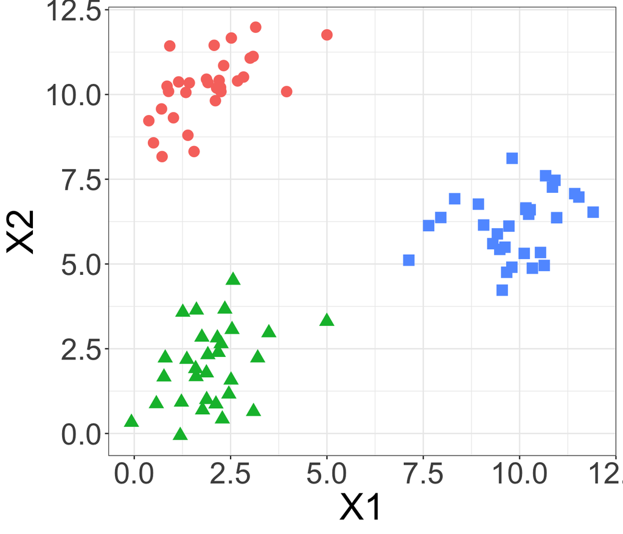

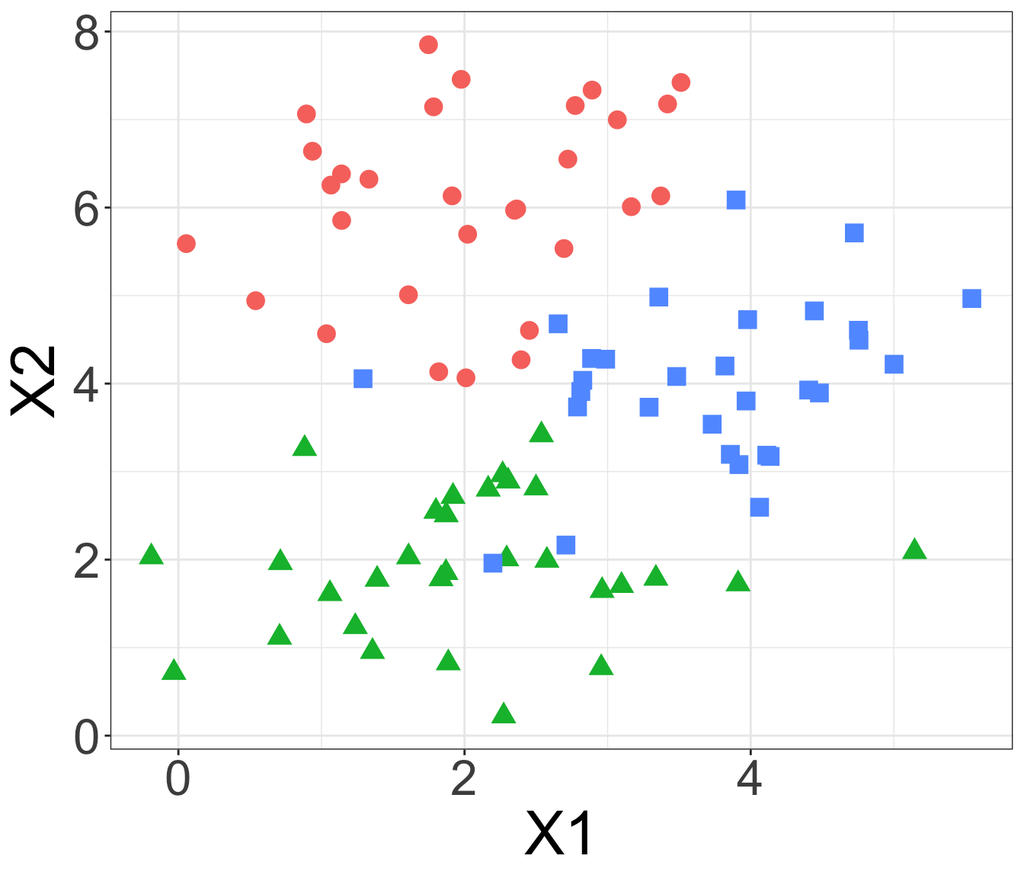

Sometimes it is not so clear whether we are in a supervised or unsupervised problem. For example, we may have $m < n$ observations with a response measurement and $n-m$ observations with no response. Why?

In this case, we want a method that can incorporate all the information we have.

# 3 Regression vs. Classification

Variables can be either quantitative or categorical.

Examples –

Age

Height

Income

Price of stock

Brand of product purchased

Cancer diagnosis

Color of cat

We tend to select statistical learning methods for supervised problems based on whether the response is quantitative or categorical.

However, when the predictors are quantitative or categorical is less important for this choice.